# reproduction APOE4*parity analysis

Clazz

2025-11-13

# WRAP

not info on gestational diabetes/preeclampsia CU exclusion is based on a “consensus” poor availability of amyloid dat hence not included

## Descriptives WRAP

| **Variables** | **N** | **0** N = 47<sup>1</sup> | **1** N = 27<sup>1</sup> | **2** N = 76<sup>1</sup> | **3** N = 37<sup>1</sup> | **4** N = 9<sup>1</sup> | **p-value**<sup>2</sup> |
| --- | --- | --- | --- | --- | --- | --- | --- |
| APOE-E4 carrier, Count (%) | 196 |  |  |  |  |  | 0.6 |
| Carrier |  | 19 (40%) | 8 (30%) | 30 (39%) | 12 (32%) | 5 (56%) |  |
| Non-Carrier |  | 28 (60%) | 19 (70%) | 46 (61%) | 25 (68%) | 4 (44%) |  |
| Education (years), Mean (SD) | 196 | 16.70 (2.91) | 16.15 (3.23) | 16.33 (2.37) | 15.70 (2.90) | 15.89 (2.32) | 0.4 |
| Age at first scan, Mean (SD) | 196 | 59 (6) | 62 (6) | 61 (7) | 63 (7) | 63 (9) | 0.14 |
| Average hippocampus volume at V1, Mean (SD) | 196 | 6.75 (0.67) | 6.78 (0.61) | 6.80 (0.75) | 6.85 (0.79) | 6.72 (1.47) | >0.9 |
| Number of visits | 196 | 3.60 (1.48) | 3.30 (1.73) | 3.26 (1.44) | 3.68 (1.89) | 2.89 (1.17) | 0.5 |
| Average span between first and last | 196 | 7.6 (4.0) | 7.0 (4.3) | 6.8 (4.0) | 6.5 (4.1) | 5.0 (4.1) | 0.4 |

<sup>1</sup> n (%); Mean (SD)  
<sup>2</sup> Fisher’s exact test; Kruskal-Wallis rank sum test

## Reproducing analysis: APOE x parity (continuous) x time - 2 visits

### Main group analysis

|  | (1) |
| --- | --- |
| Intercept | 6.974 *** |
|  | (0.551) |
| Parity | 0.081 |
|  | (0.057) |
| APOE_E4 Carrier | 0.018 |
|  | (0.181) |
| Age baseline | -0.027 *** |
|  | (0.008) |
| TIV | 0.045 *** |
|  | (0.011) |
| Parity * APOE4 | -0.096 |
|  | (0.089) |
| Parity * time | -0.002 |
|  | (0.005) |
| APOE4 * time | -0.039 * |
|  | (0.016) |
| Parity * APOE4 * time | -0.002 |
|  | (0.009) |
| N | 380 |
| logLik | -180.662 |
| AIC | 397.324 |
| † p < 0.1; * p < 0.05; ** p < 0.01; *** p < 0.001. |  |

### APOE neg only

|  | (1) |
| --- | --- |
| Intercept | 6.575 *** |
|  | (0.725) |
| Parity | 0.075 |
|  | (0.057) |
| Age baseline | -0.022 * |
|  | (0.010) |
| TIV | 0.029 ** |
|  | (0.009) |
| Parity * time | -0.004 |
|  | (0.003) |
| N | 236 |
| logLik | -66.683 |
| AIC | 157.367 |
| † p < 0.1; * p < 0.05; ** p < 0.01; *** p < 0.001. |  |

### APOE pos only

|  | (1) |
| --- | --- |
| Intercept | 7.446 *** |
|  | (0.804) |
| Parity | -0.008 |
|  | (0.072) |
| Age baseline | -0.033 ** |
|  | (0.012) |
| TIV | 0.086 ** |
|  | (0.027) |
| Parity * time | -0.002 |
|  | (0.010) |
| N | 144 |
| logLik | -94.307 |
| AIC | 214.614 |
| † p < 0.1; * p < 0.05; ** p < 0.01; *** p < 0.001. |  |

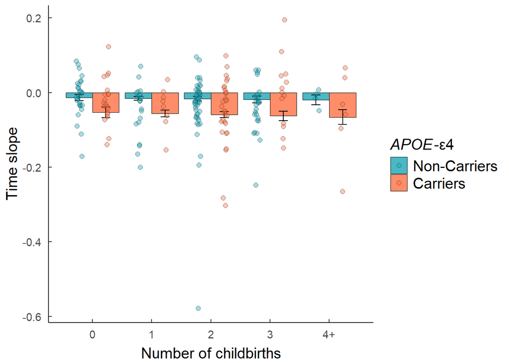

## Reproducing analysis: APOE x parity (continuous) x time - all visits

### Main group analysis

[output not shown]

### APOE neg only

|  | (1) |
| --- | --- |
| Intercept | 6.932 *** |
|  | (0.706) |
| Parity | 0.086 |
|  | (0.057) |
| Age baseline | -0.026 * |
|  | (0.010) |
| TIV | 0.024 *** |
|  | (0.007) |
| Parity * time | -0.006 *** |
|  | (0.001) |
| N | 445 |
| logLik | -19.110 |
| AIC | 64.221 |
| † p < 0.1; * p < 0.05; ** p < 0.01; *** p < 0.001. |  |

### APOE pos only

|  | (1) |
| --- | --- |
| Intercept | 7.659 *** |
|  | (0.809) |
| Parity | 0.005 |
|  | (0.070) |
| Age baseline | -0.037 ** |
|  | (0.012) |
| TIV | 0.048 *** |
|  | (0.014) |
| Parity * time | -0.003 |
|  | (0.003) |
| N | 259 |
| logLik | -99.473 |
| AIC | 224.947 |
| † p < 0.1; * p < 0.05; ** p < 0.01; *** p < 0.001. |  |

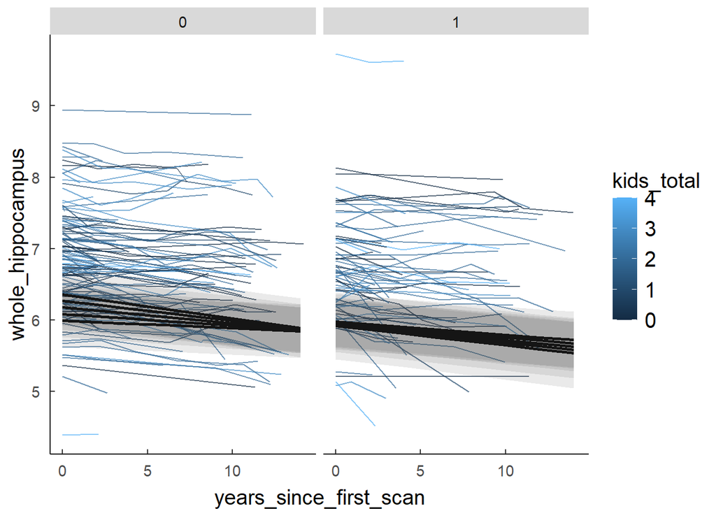

# HABS HD

- HABS HD neuroimaging data was technically pulled form their website for quality checks
- ASHS values oddly small and jordi doesn’t understand eitehr the slices thing
- Some incoherences like hughe amount of NAs for TIV compared with available neuroimaging data and 2 different values that cannot be used together or only used as an average which seems odd
- Results were null once adjusting for all variables as stated in imaging: scanner, TIV, number of slices
- lots of missings once including all covariates
- maybe adjusting for social variables would help?